# Prueba Huli

## Análisis de resultados

Inicialmente se tiene la siguiente distribución de los médicos analizados conforme a su permanencia en la plataforma.

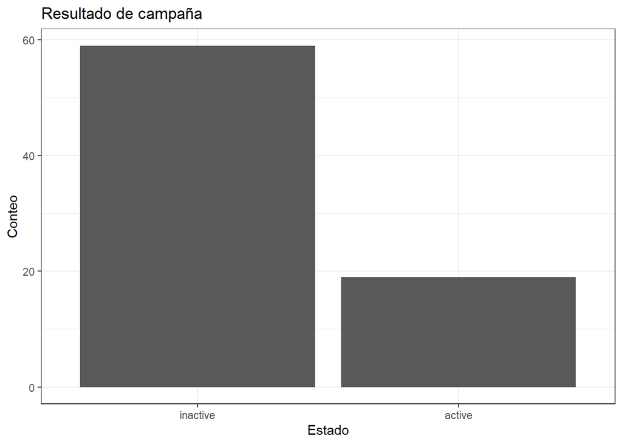

```r
data %>% ggplot(aes(x = state)) + geom_bar() +
    theme_bw() + labs(title = "Resultado de campaña", x = "Estado", y = "Conteo")
```

El resultado es que un 24.4% de los médicos observados permaneció una vez terminado el periodo de prueba.

El siguiente gráfico muestra los resultados por país.

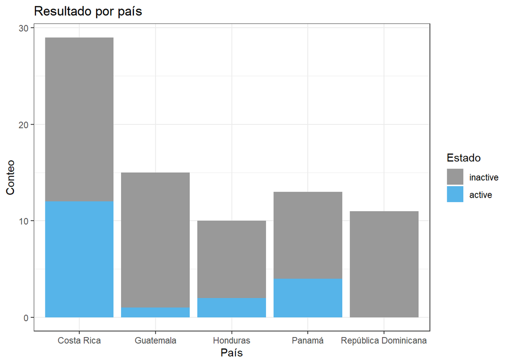

```r
data %>% ggplot(aes(x = country, fill = state)) + geom_bar() +
    theme_bw() + labs(title = "Resultado por país", x = "País", y = "Conteo") +
    guides(fill = guide_legend(title="Estado")) +
    scale_fill_manual(values=c("#999999", "#56B4E9"))
```

Se observa que existe gran diferencia entre la permanencia de los médicos de los diferentes países. Por ejemplo, se observa que la tasa de permanencia para Costa Rica es cercana al 50%, mientras que para República Dominicana es 0. Países como Guatemala y Honduras también presentan tasas de permanencia bajas.

Si se realiza un gráfico similar pero con la variable especialidad se observa lo siguiente:

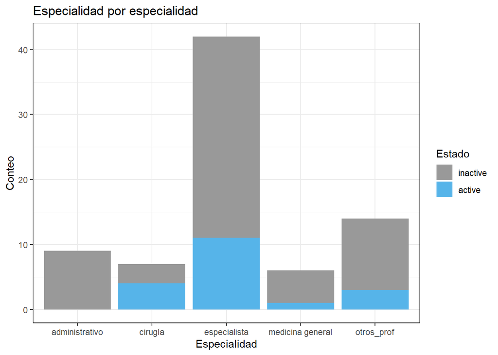

```r
data %>% ggplot(aes(x = grouped_specialty, fill = state)) + geom_bar() +
    theme_bw() + labs(title = "Especialidad por especialidad", x = "Especialidad", y = "Conteo") +
    guides(fill = guide_legend(title="Estado")) +
    scale_fill_manual(values=c("#999999", "#56B4E9"))
```

Finalmente, para la variable n_specialties el resultado es:

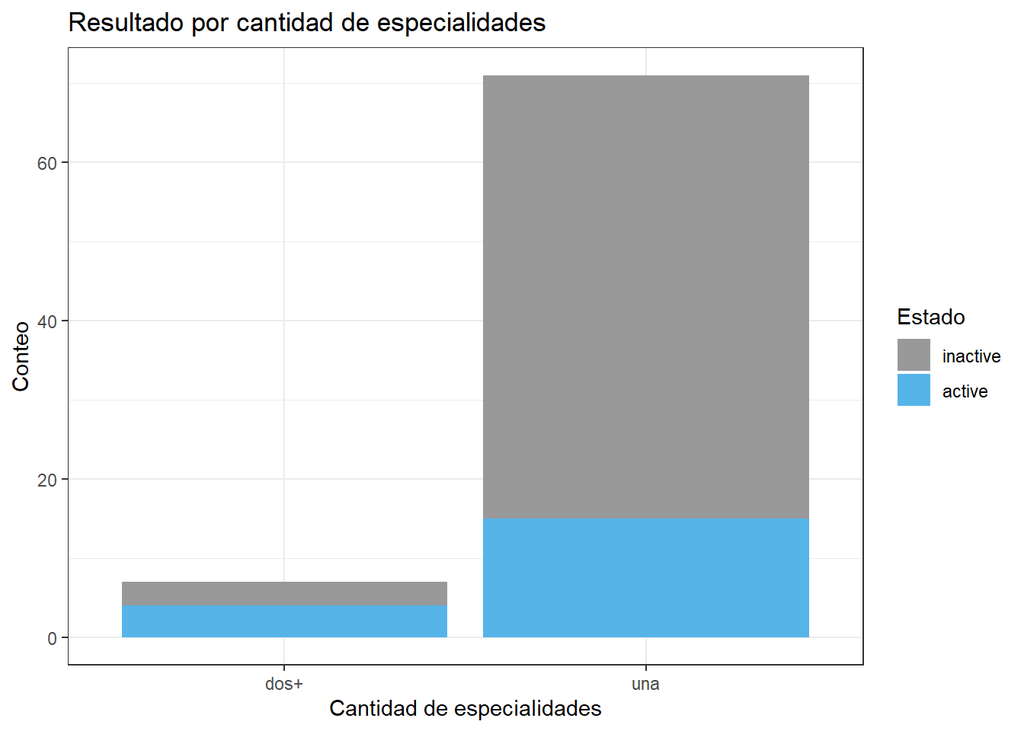

```r
data %>% ggplot(aes(x = n_specialties, fill = state)) + geom_bar() +
    theme_bw() + labs(title = "Resultado por cantidad de especialidades", x = "Cantidad de especialidades", y = "Conteo") +
    guides(fill = guide_legend(title="Estado")) +
    scale_fill_manual(values=c("#999999", "#56B4E9"))
```

El gráfico muestra que la permancia de los médicos con más de una especialidad es considerablemente mayor que los que poseen solamente una. Sin embargo, la cantidad de médicos con dos o más especialidades es baja por lo que podría no ser estadísticamente representativa.

## Modelado de la información

En esta sección se evaluó existen diferencias estadísticamente significativas entre las categorías de las diferentes variables para identificar si un usuario permanece o no activo una vez finalizado el periodo de prueba. Para esto se construyó un modelo de regresión logística utilizando como variable respuesta “state” y como predictoras “country”, “grouped_specialty” y “n_specialties”.

El resultado inicial del modelo es:

```r
glm_model <- glm(state ~ ., family = "binomial", data = data)
summary(glm_model)
```

```
##
## Call:
## glm(formula = state ~ ., family = "binomial", data = data)
##
## Deviance Residuals:
##      Min        1Q    Median        3Q       Max
## -1.55178  -0.69766  -0.12508  -0.00003   2.34671
##
## Coefficients:
##                                    Estimate Std. Error z value Pr(>|z|)
## (Intercept)                        -16.4117  3310.3130  -0.005   0.9960
## countryGuatemala                    -2.3372     1.2374  -1.889   0.0589 .
## countryHonduras                     -1.5453     1.0904  -1.417   0.1564
## countryPanamá                       -0.9385     0.9340  -1.005   0.3150
## countryRepública Dominicana        -21.1504  2800.5056  -0.008   0.9940
## grouped_specialtycirugía            20.3795  3310.3129   0.006   0.9951
## grouped_specialtyespecialista       18.2431  3310.3127   0.006   0.9956
## grouped_specialtymedicina general   17.4800  3310.3128   0.005   0.9958
## grouped_specialtyotros_prof         18.5345  3310.3127   0.006   0.9955
## n_specialtiesuna                    -2.1819     1.4676  -1.487   0.1371
## ---
## Signif. codes:  0 '***' 0.001 '**' 0.01 '*' 0.05 '.' 0.1 ' ' 1
##
## (Dispersion parameter for binomial family taken to be 1)
##
##     Null deviance: 86.608  on 77  degrees of freedom
## Residual deviance: 57.997  on 68  degrees of freedom
## AIC: 77.997
##
## Number of Fisher Scoring iterations: 18
```

Con base en los P-Values (medida que indica si un coeficiente es estadísticamente significativo) se observa que la variable de especialidad tiene poca relevancia en el modelo. Para las otras dos variables, los coeficientes aún son altos como para establecer una significancia.

Se decidió realizar un analisis de stepwise para identificar el mejor modelo en términos del AIC el cuál es un estimador del error de predicción y es comunmente uilizado en la selección de modelos de regresión.

El resultado es el siguiente:

```r
glm_model2 <- stepAIC(glm_model)
```

```
## Start:  AIC=78
## state ~ country + grouped_specialty + n_specialties
##
##                     Df Deviance    AIC
## - grouped_specialty  4   65.710 77.710
## <none>                   57.997 77.997
## - n_specialties      1   60.730 78.730
## - country            4   76.530 88.530
##
## Step:  AIC=77.71
## state ~ country + n_specialties
##
##                 Df Deviance   AIC
## <none>                65.71 77.71
## - n_specialties  1    72.74 82.74
## - country        4    82.78 86.78
```

```r
summary(glm_model2)
```

```
##
## Call:
## glm(formula = state ~ country + n_specialties, family = "binomial",
##     data = data)
##
## Deviance Residuals:
##      Min        1Q    Median        3Q       Max
## -1.11311  -0.85758  -0.28001  -0.00007   2.55287
##
## Coefficients:
##                              Estimate Std. Error z value Pr(>|z|)
## (Intercept)                    2.4698     1.3890   1.778   0.0754 .
## countryGuatemala              -2.6229     1.2753  -2.057   0.0397 *
## countryHonduras               -1.2489     0.9964  -1.253   0.2101
## countryPanamá                 -0.2145     0.7249  -0.296   0.7673
## countryRepública Dominicana  -19.2705  1734.7278  -0.011   0.9911
## n_specialtiesuna              -3.0662     1.3775  -2.226   0.0260 *
## ---
## Signif. codes:  0 '***' 0.001 '**' 0.01 '*' 0.05 '.' 0.1 ' ' 1
##
## (Dispersion parameter for binomial family taken to be 1)
##
##     Null deviance: 86.608  on 77  degrees of freedom
## Residual deviance: 65.710  on 72  degrees of freedom
## AIC: 77.71
##
## Number of Fisher Scoring iterations: 17
```

```r
1 - round(exp(glm_model2$coefficients),3)
```

```
##                 (Intercept)            countryGuatemala
##                     -10.820                       0.927
##             countryHonduras               countryPanamá
##                       0.713                       0.193
## countryRepública Dominicana            n_specialtiesuna
##                       1.000                       0.953
```

Los coeficientes pueden ser interpretados de la siguiente manera: En el caso de la variable de country la categoría de referencia es Costa Rica por lo que los resultados serán en comparación a dicha categoría. Por ejemplo, para el caso de Guatemala, la probabilidad de permanecer activo es 92.7 menor que la de un médico costarricense. Similarmente, la probabilidad de que un médico hondureño permanezca activo es un 71.3% menor que la de un médico costarricense.

En el caso de las especialidades, la probabilidad de que un médico con una especilidad permanezca activo es 95.3% menor que la de un médico con 2 o más.

### Respuestas y comentarios finales

Con base en el modelo planteado se observa que la especialidad médica no tiene mayor influencia en el éxito de la compra. Sin embargo, se observó que existen categorías como la administrativa que tuvieron nula respuesta. Considero que el resultado en esta categoría es esperable ya que pienso que la relación es inversa. Un médico administrativo saldría a buscar trabajo en una empresa o hospital, más que una institución buscar al profesional dentro de la plataforma.

Valdría la pena incrementar la base de datos en busca de una mayor claridad en la importancia de esta variable. Otra opción es probar con otra clasificación de las especialidades, diferente a la que se propuso en esta solución. En general, no descartaría la variable hasta trabajar un poco más con ella.

El modelo planteado muestra que el país de procedencia muestra que si tiene efecto estadísticamente significativo en el éxito de la compra. Por lo qué es de gran importancia identificar las diferencias entre los médicos de los paises en búsqueda de explicación a este fenómeno.

A nivel general considero que para determinar si la campaña fue exitosa o no es necesario conocer el objetivo con el que esta fue planteada. ¿Cual era el porcentaje de respuesta esperado? ¿Cuáles han sido resultados de campañas previas?. Al realizar una breve búsqueda en internet a cerca de tasas de respuestas en compañias SaaS encontré que las tasas de respuesta promedio son menores que la obtenida en esta campaña por lo que con la información disponible la consideraría como exitosa.

Como comentario final, creo que la información proporcionada es insuficiente si se desea explicar con más profundidad el porqué un médico continuó o no activo al finalizar el periodo de prueba. Sería interesante poder contar con variables como cantidad de citas agendadas en el periodo de prueba, cantidad de visitas al perfil del médico, cantidad de ingresos del médico al sistema, calidad del perfil del médico en el sistema, entre otros para intentar explicar el fenómeno. Además, esto ayudaría a identificar médicos que podrían cancelar su plan al finalizar el periodo de prueba antes de que esto suceda y aplicar estrategias para mantenerlos.